# Ocean Plastic: Where does it come from and what does that mean for us?

Andy Nguyen, Julia Russel, Jasmine Wong

11/14/2022

## Summary Paragraph

These are some summary information regarding our datasets from our project. In the first dataset, it showed that Philippines had the highest amount of plastic ending up in the ocean. The fourth dataset also found that the Philippines emitted the most plastic waste to the ocean. The second dataset shows that the most common micro-plastic type found in San Francisco bay was Not Characterized. The third dataset proved that the most common item found along beaches and coastlines were Cigarette butts. From the fifth dataset, it showed that plastic poses a great threat to fish because the fish with most plastic per individual was Asian sea bass.

## Tables

### Table 1

```
##        Country Tons_in_Ocean
## 1   Bangladesh        136404
## 2       Brazil        300874
## 3        China        501877
## 4        India        555144
## 5    Indonesia        327189
## 6     Malaysia        213562
## 7      Myanmar        115864
## 8  Philippines        947189
## 9       Turkey        164625
## 10     Vietnam        172188
```

This table shows the top 10 countries that put the most plastic (in tons) in the ocean. This data helps answer the question “Where is ocean plastic coming from?” Thus, it gives us a little more insight on some of the countries that are major players in terms of polluting the ocean with plastic. This is important because it lets policymakers know where to restrict sending ocean waste to and where to start making policies to put tighter restrictions on ocean waste and trash management

### Table 2

```
## # A tibble: 10 × 2
##    PlasticType                  TotalFound
##    <chr>                             <int>
##  1 Acrylic                             243
##  2 Anthropogenic (cellulosic)          391
##  3 Anthropogenic (unknown base)       1545
##  4 Not Characterized                 37107
##  5 Polyester                           364
##  6 Polyethylene                       1174
##  7 Polypropylene                       507
##  8 Polystyrene                         399
##  9 Unknown                             488
## 10 Unknown Potentially Rubber          298
```

This table shows the top 10 types of microplastic that were found in the San Francisco bay and surrounding waters. This helps us understand what types of microplastics are most commonly found. We can use San Francisco as a case study in which other coastal areas can understand what microplastics might be prevalent in their area and start finding ways to limit those microplastics. Also, this information gives us an idea on which microplastics we need to research on their effects on the human body.

### Table 3

```
##                Common.name Mean.num.particles.per.indv         Habitat
## 1           Asian sea bass                 1268.500000        demersal
## 2              Whale shark                   38.000000 pelagic-oceanic
## 3            Crevalle jack                   30.700000 reef-associated
## 4       Whitemouth croaker                   12.100000        demersal
## 5       Whitemouth croaker                   12.100000        demersal
## 6       Golden gray mullet                    9.450000 pelagic-neritic
## 7         Coco sea catfish                    9.142857        demersal
## 8               Bonnethead                    9.000000 reef-associated
## 9              Common sole                    8.566604        demersal
## 10 Gafftopsail sea catfish                    7.800000        demersal
## 11       Gilthead seabream                    7.300000        demersal
## 12         Bluefin gurnard                    7.300000        demersal
## 13      Bigfin lanternfish                    7.200000 pelagic-oceanic
## 14 Daggertooth pike conger                    7.000000        demersal
## 15 Three-lined tounge sole                    6.900000        demersal
## 16            Light maigre                    6.500000        demersal
## 17     Ocellate spot skate                    6.500000        demersal
## 18          Kammal thryssa                    6.315789 pelagic-neritic
## 19            Light maigre                    6.200000        demersal
## 20      Golden lanternfish                    6.000000    bathypelagic
```

This table shows which fish species per individual had the most plastic in them. This is important because it answers the question on how plastics are affecting the ocean ecosystems, and this shows that it is greatly threatening the lives that live in it. The harmful effects of plastic, even if it was just in one fish species, can affect every other species as well. Furthermore, the threats that plastic poses to the ocean will also threaten many people’s way of life too, since many people rely on the ocean for necessities such as their diet. Showing the harm done to fish species can influence policymakers to create policies to combat plastic waste within the ocean.

### Table 4

```
##                Country     Waste
## 1              Jamaica 0.7917232
## 2               Belize 0.9589744
## 3              Grenada 1.1607143
## 4               Panama 1.2333961
## 5               Guyana 1.5913155
## 6             Malaysia 2.2878873
## 7          Saint Lucia 2.4535519
## 8  Trinidad and Tobago 2.5498208
## 9             Suriname 2.8864028
## 10         Philippines 3.2961606
```

We included this table to show the top ten countries that emit the most waste per capita by kilograms per year in 2019. This data answers the question: “What top ten countries emit the most plastic waste?” The top ten country that emitted the most plastic into the ocean is the Philippines. The top ten country that emitted the least amount of plastic was Jamaica. This information is important because it provides proof that will influence policymakers to create policies in these countries that will prevent plastic waste emission into the ocean.

### Table 5

```
##                Characteristic Number_of_items
## 1             Cigarette butts          964512
## 2               Food wrappers          627014
## 3                 Other trash          519438
## 4         Plastic bottle caps          409855
## 5        Plastic grocery bags          272399
## 6            Straws, stirrers          224170
## 7 Plastic take out containers          222289
## 8               Beverage cans          162750
## 9      Glass beverage bottles          146255
```

This table is included because it shows the most common items found on coastlines. The most common item found was cigarette butts, and the least common item found was glass beverage bottles. This data proves to policymakers that items like cigarette butts, food wrappers, plastic bottle caps, and plastic bags are ending up on coastlines and can harm the environment, marine animals, and people who frequent the beach or the coast. The goal is for this data to influence policymakers to create regulations and policies that will prevent littering and better trash management.

## Chart One

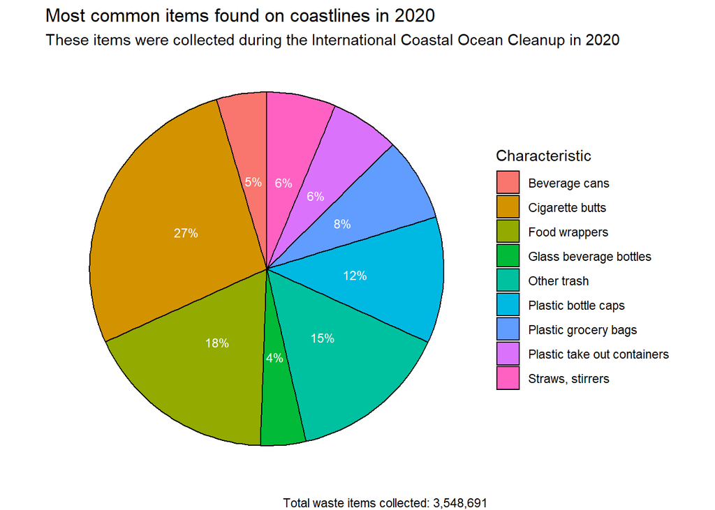

This chart serves the purpose of answering the third research question: “What are common waste items that end up on beaches and shorelines?” This chart shows the proportions of the most common items found on coastlines that were collected during the International Coastal Ocean Cleanup in 2020. There were 3,548,691 items collected. The most common item found was cigarette butts with a 27% of all the items collected. The least common item that was found was glass beverage bottles with a 4% of all the items collected.

## Chart Two

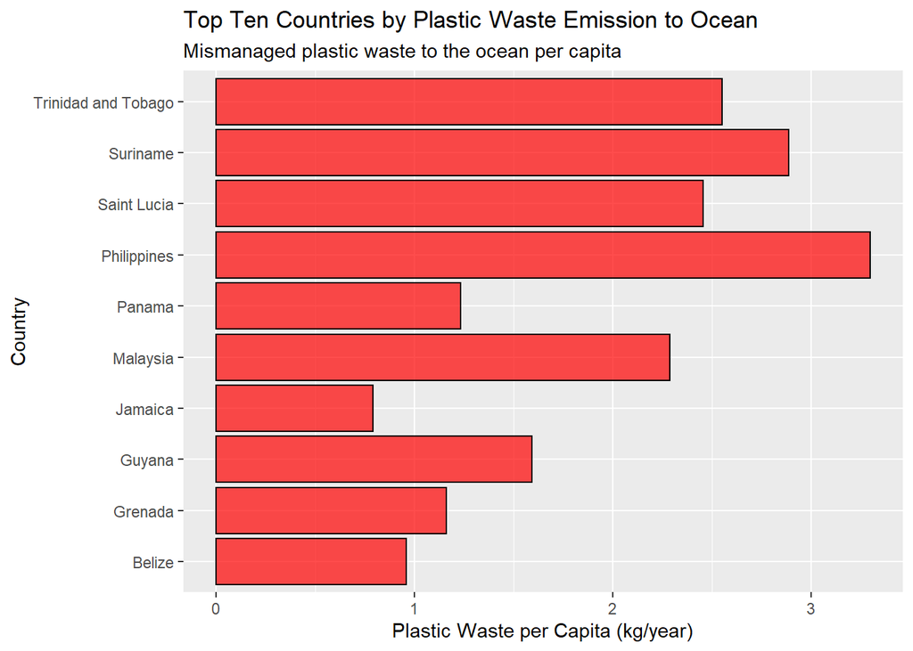

This chart serves the purpose of answering the fourth research question: “What top ten countries emit the most plastic waste?” This chart shows the top ten countries that emit the most plastic waste to the ocean per capita in kilograms per year. The country that emits the most waste per capita is the Philippines with over three kilograms (3.296 kg/yr) of mismanaged plastic waste to the ocean per year. The country that emits the least per capita (in the top ten) is Jamaica with less than one kilogram (0.792 kg/yr) of mismanaged plastic waste to the ocean per year.